# Communicating Data: Ford GoBike TripData Exploration For February 2019

## Introduction

> This dataset contains 183412 instances of trips around San Francisco Bay area, with 16 feature variables which includes duration for trip and start and end time of trips.This dataset contains instances of trips just for the month of february 2019.

## Preliminary Wrangling

```python
import pandas as pd
import numpy as np
import matplotlib.pyplot as plt
import seaborn as sb
%matplotlib inline
```

```python
ford_bike=pd.read_csv('201902-fordgobike-tripdata.csv')
```

## Assess

```python
ford_bike.shape
```

```
(183412, 16)
```

```python
ford_bike.head(10)
```

|  | duration_sec | start_time | end_time | start_station_id | start_station_name | start_station_latitude | start_station_longitude | end_station_id | end_station_name | end_station_latitude | end_station_longitude | bike_id | user_type | member_birth_year | member_gender | bike_share_for_all_trip |
| --- | --- | --- | --- | --- | --- | --- | --- | --- | --- | --- | --- | --- | --- | --- | --- | --- |
| 0 | 52185 | 2019-02-28 17:32:10.1450 | 2019-03-01 08:01:55.9750 | 21.0 | Montgomery St BART Station (Market St at 2nd St) | 37.789625 | -122.400811 | 13.0 | Commercial St at Montgomery St | 37.794231 | -122.402923 | 4902 | Customer | 1984.0 | Male | No |
| 1 | 42521 | 2019-02-28 18:53:21.7890 | 2019-03-01 06:42:03.0560 | 23.0 | The Embarcadero at Steuart St | 37.791464 | -122.391034 | 81.0 | Berry St at 4th St | 37.775880 | -122.393170 | 2535 | Customer | NaN | NaN | No |
| 2 | 61854 | 2019-02-28 12:13:13.2180 | 2019-03-01 05:24:08.1460 | 86.0 | Market St at Dolores St | 37.769305 | -122.426826 | 3.0 | Powell St BART Station (Market St at 4th St) | 37.786375 | -122.404904 | 5905 | Customer | 1972.0 | Male | No |
| 3 | 36490 | 2019-02-28 17:54:26.0100 | 2019-03-01 04:02:36.8420 | 375.0 | Grove St at Masonic Ave | 37.774836 | -122.446546 | 70.0 | Central Ave at Fell St | 37.773311 | -122.444293 | 6638 | Subscriber | 1989.0 | Other | No |
| 4 | 1585 | 2019-02-28 23:54:18.5490 | 2019-03-01 00:20:44.0740 | 7.0 | Frank H Ogawa Plaza | 37.804562 | -122.271738 | 222.0 | 10th Ave at E 15th St | 37.792714 | -122.248780 | 4898 | Subscriber | 1974.0 | Male | Yes |
| 5 | 1793 | 2019-02-28 23:49:58.6320 | 2019-03-01 00:19:51.7600 | 93.0 | 4th St at Mission Bay Blvd S | 37.770407 | -122.391198 | 323.0 | Broadway at Kearny | 37.798014 | -122.405950 | 5200 | Subscriber | 1959.0 | Male | No |
| 6 | 1147 | 2019-02-28 23:55:35.1040 | 2019-03-01 00:14:42.5880 | 300.0 | Palm St at Willow St | 37.317298 | -121.884995 | 312.0 | San Jose Diridon Station | 37.329732 | -121.901782 | 3803 | Subscriber | 1983.0 | Female | No |
| 7 | 1615 | 2019-02-28 23:41:06.7660 | 2019-03-01 00:08:02.7560 | 10.0 | Washington St at Kearny St | 37.795393 | -122.404770 | 127.0 | Valencia St at 21st St | 37.756708 | -122.421025 | 6329 | Subscriber | 1989.0 | Male | No |
| 8 | 1570 | 2019-02-28 23:41:48.7900 | 2019-03-01 00:07:59.7150 | 10.0 | Washington St at Kearny St | 37.795393 | -122.404770 | 127.0 | Valencia St at 21st St | 37.756708 | -122.421025 | 6548 | Subscriber | 1988.0 | Other | No |
| 9 | 1049 | 2019-02-28 23:49:47.6990 | 2019-03-01 00:07:17.0250 | 19.0 | Post St at Kearny St | 37.788975 | -122.403452 | 121.0 | Mission Playground | 37.759210 | -122.421339 | 6488 | Subscriber | 1992.0 | Male | No |

```python
ford_bike.info()
```

```
<class 'pandas.core.frame.DataFrame'>
RangeIndex: 183412 entries, 0 to 183411
Data columns (total 16 columns):
 #   Column                   Non-Null Count   Dtype
---  ------                   --------------   -----
 0   duration_sec             183412 non-null  int64
 1   start_time               183412 non-null  object
 2   end_time                 183412 non-null  object
 3   start_station_id         183215 non-null  float64
 4   start_station_name       183215 non-null  object
 5   start_station_latitude   183412 non-null  float64
 6   start_station_longitude  183412 non-null  float64
 7   end_station_id           183215 non-null  float64
 8   end_station_name         183215 non-null  object
 9   end_station_latitude     183412 non-null  float64
 10  end_station_longitude    183412 non-null  float64
 11  bike_id                  183412 non-null  int64
 12  user_type                183412 non-null  object
 13  member_birth_year        175147 non-null  float64
 14  member_gender            175147 non-null  object
 15  bike_share_for_all_trip  183412 non-null  object
dtypes: float64(7), int64(2), object(7)
memory usage: 22.4+ MB
```

```python
ford_bike.isnull().sum()
```

```
duration_sec                  0
start_time                    0
end_time                      0
start_station_id            197
start_station_name          197
start_station_latitude        0
start_station_longitude       0
end_station_id              197
end_station_name            197
end_station_latitude          0
end_station_longitude         0
bike_id                       0
user_type                     0
member_birth_year          8265
member_gender              8265
bike_share_for_all_trip       0
dtype: int64
```

```python
ford_bike.duplicated().sum()
```

```
0
```

### Assessment

#### Quality

- There are null values in start_station_id, start_station_name, end_station_id, end_station_name, member_birth_year and member_gender. this should be dropped as there is no way of getting these data.
- member_birth_year should be int
- Start and End times should be in datetime format.
- user_type,member_gender and bike_share_for_all_trip should be changed to categorical.
- since we will be concerned with day of the week and time of the day it will be wise to create new columns for these.
- it will be more readable putting the duration_sec variable in minutes.
- it would be nice to convert our member_birth_year to actual user age.

### Cleaning

```python
fordbike=ford_bike.copy()
```

```python
# Addressing the first bullet point
fordbike.dropna(axis=0,inplace=True)
```

```python
# check for null
fordbike.isnull().sum()
```

```
duration_sec               0
start_time                 0
end_time                   0
start_station_id           0
start_station_name         0
start_station_latitude     0
start_station_longitude    0
end_station_id             0
end_station_name           0
end_station_latitude       0
end_station_longitude      0
bike_id                    0
user_type                  0
member_birth_year          0
member_gender              0
bike_share_for_all_trip    0
dtype: int64
```

```python
# create function to check type
def check_type(x):
    for var in x:
        print(f'{var} ----> {fordbike[var].dtype}')
```

```python
# convert usertype, member_gender bike_share_for_all_trip to categorical type
varss =['user_type','member_gender','bike_share_for_all_trip']
for var in varss:
    fordbike[var]=fordbike[var].astype('category')
# check conversion
check_type(varss)
```

```
user_type ----> category
member_gender ----> category
bike_share_for_all_trip ----> category
```

```python
# convert start_time and end_time to datetime format
varss=['start_time','end_time']
for var in varss:
    fordbike[var]=pd.to_datetime(fordbike[var])

check_type(varss)
```

```
start_time ----> datetime64[ns]
end_time ----> datetime64[ns]
```

```python
# convert birth year to int
fordbike.member_birth_year=fordbike.member_birth_year.astype('int')
```

```python
# extract am or pm and store in new column
fordbike['time_of_day']=pd.to_datetime(fordbike.start_time).dt.strftime('%p')
# check column
fordbike.time_of_day
```

```
0         PM
2         PM
3         PM
4         PM
5         PM
          ..
183407    AM
183408    AM
183409    AM
183410    AM
183411    AM
Name: time_of_day, Length: 174952, dtype: object
```

```python
# extract day of the week to 'day_of_week' column
fordbike['day_of_week']=pd.to_datetime(fordbike.start_time).dt.strftime('%A')
# check column
fordbike['day_of_week']
```

```
0         Thursday
2         Thursday
3         Thursday
4         Thursday
5         Thursday
            ...
183407      Friday
183408      Friday
183409      Friday
183410      Friday
183411      Friday
Name: day_of_week, Length: 174952, dtype: object
```

```python
# rename duration_sec to duration_min and convert to int
def renameColumn(old_name,new_name):
    fordbike.rename(columns={old_name:new_name},inplace=True)
# change column name
renameColumn('duration_sec','duration_min')
fordbike.duration_min=fordbike.duration_min / 60
# fordbike.duration_min=fordbike.duration_min.astype('int')

# check fordbike.duration_min column
fordbike.duration_min
```

```
0          869.750000
2         1030.900000
3          608.166667
4           26.416667
5           29.883333
             ...
183407       8.000000
183408       5.216667
183409       2.350000
183410       2.316667
183411       4.516667
Name: duration_min, Length: 174952, dtype: float64
```

```python
# rename member_birth_year to user_age
renameColumn('member_birth_year','user_age')
# convert birth_year to age
fordbike.user_age=fordbike.start_time.dt.year - fordbike.user_age
```

### The main feature(s) of interest in this dataset

- I am most interested in time spent using the service and what category of users use the service most.This will help Ford go-bike to customize their services or dig deeper to find ways of involving a wider category of people.
- I will also like to find out what is the most famous destination for the users of this service.

### Features in the dataset that will help support investigation into feature(s) of interest

- member_gender
- bike_share_for_all_trip
- user_type
- duration_min
- end_station_id

## Univariate Exploration

### Question 1

Is duration_min unimodal?

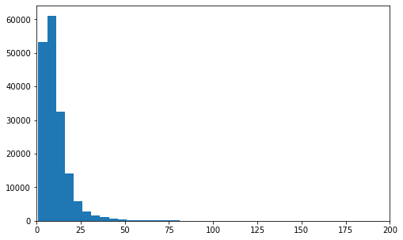

```python
# functioon for plotting
def plot_hist(data,size,var,log_plot=False):
    if log_plot:
        plt.figure(figsize=[8, 5]);
        bins=10**np.arange(np.log10(data['duration_min'].min()),np.log10(data['duration_min'].max())+size,size)
        plt.hist(data=data,x=var,bins=bins);
        plt.xscale('log');

    else:
        plt.figure(figsize=[8, 5]);
        bins=np.arange(data[var].min(),data[var].max()+size,size)
        plt.hist(data=data,x=var,bins=bins);

# plotting the graph
plot_hist(fordbike,5,'duration_min',log_plot=False);
plt.xlim(0,200);
```

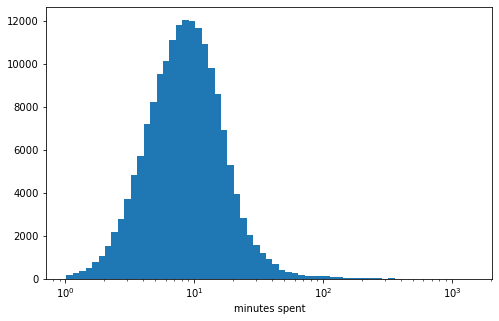

```python
# plotting on a log scale
plot_hist(fordbike,0.05,'duration_min',log_plot=True)
plt.xlabel('minutes spent');
```

### Observation

Due to the long tail of the right skewed hist linear distribution a log plot had to be plotted which revealed the unimodal nature of the duration_min feature.

### Question 2

What stations are people going to the most?

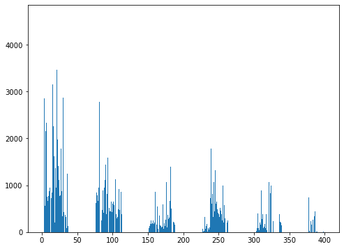

```python
plt.figure(figsize=[8,6])
bins=np.arange(0,fordbike.end_station_id.max()+3,0.5)
plt.hist(data=fordbike,x='end_station_id',bins=bins);
```

### Observation

Investigating the user destination variable reveals the destinations with hieghest traffic which are destinations with id around

- 3-35 (Powell St BART Station (Market St at 4th St) - Cahil Park)
- 75-120 (Market St at Franklin St -Mission Dolores Park)
- 175 (49th St at Telegraph Ave )
- 250 (North Berkeley BART Station)

### Question 3

What is the age distribution?

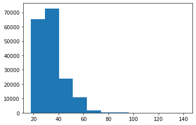

```python
size = (fordbike.user_age.max() - fordbike.user_age.min()) / 11
bins=np.arange(fordbike.user_age.min(),fordbike.user_age.max()+2,size)
plt.hist(data=fordbike,x='user_age',bins=bins);
```

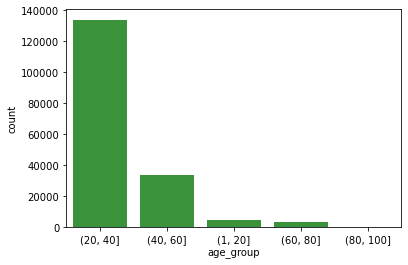

```python
# creating an age_group column to help me see the distribution clearly and easily
fordbike['age_group'] = pd.cut(x=fordbike['user_age'], bins=[1, 20, 40, 60,80, 100])
# We can check the frequency of each bin
order=fordbike['age_group'].value_counts().index
color = sb.color_palette()[2]
# plot graph
sb.countplot(data=fordbike,x='age_group',color=color,order=order);
```

### Observation

This distribution shows that majority of users are between 20 - 40 years old which is understandable as more elderly people might not be inclined to use a bike.

### Question 4

What is the user_type distribution?

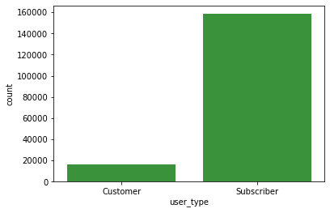

```python
sb.countplot(data=fordbike,x='user_type',color=color);
```

### Observation

This shows that for this month `subscribers` tend to use the service more.

### Question 5

What is the member_gender distribution?

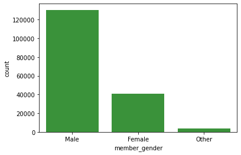

```python
order=fordbike.member_gender.value_counts().index
sb.countplot(data=fordbike,x='member_gender',color=color,order=order);
```

### Observation

This plot shows that more "males" patronize the service than "females" and the "others" gender.

### Question 6

What day has the most engagement by users?

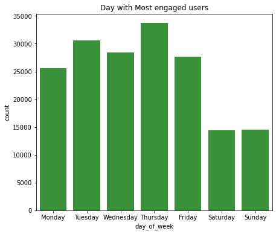

```python
plt.figure(figsize=[7,6])
color=sb.color_palette()[2]
days=['Monday','Tuesday','Wednesday','Thursday','Friday','Saturday','Sunday']
sb.countplot(data=fordbike,x='day_of_week',color=color,order=days).set(title='Day with Most engaged users');
```

### Observation

We see that thursday has the heighest number of users

### Question 7

What is the distribution of users by time of the day?

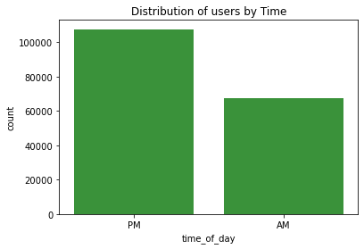

```python
sb.countplot(data=fordbike,x='time_of_day',color=color).set(title='Distribution of users by Time');
```

### Observation

This shows there is more engagement in the afternoons and evenings than in the morning.

### Question 8

Do poeple like the bike share for all service?

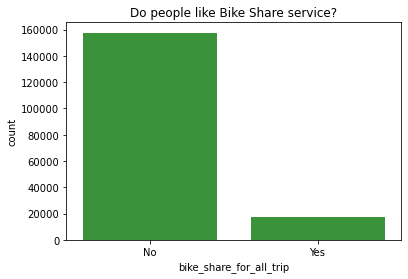

```python
sb.countplot(data=fordbike,x='bike_share_for_all_trip',color=color).set(title='Do people like Bike Share service?');
```

### Observation

Many poeple dont use the bike share for all trip

### Discussion on the distribution(s) of variable(s) of interest.

To investigate what time of day had more engagement by users i had to extract the AM or PM from the start_time variable and store in a new variable(time_of_day). I used the start_time instead of the end_time because if a person starts using the bike in the afternoon or evening it is most likely he will stop in the evening or afternoon also, but if i use the end_time i might not really capture what i want as someone can begin in AM and end in PM.

### Unusual distributions and operations performed on the data to adjust and change the form of the data.

I created a qualitative variable of age from the user_age variable to help me view and interprete the relationships better. I dropped missing data from the dataset and the member_gender,end_station_id and member_birth_year columns were affected. 197 instances in the end_station_id which amounts to 0.1% of the data and 8265 instances on the member_gender, member_birth_year which is about 4.5% of the data.

## Bivariate Exploration

### Question 1

To start off with, I want to look at the pairwise relationships present between features in the data. Is there a relationship between age and duration minutes?

##### visualizing statistics information

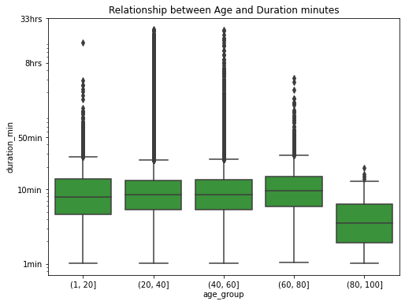

```python
# fordbike['age_group'].value_counts()
plt.figure(figsize=[8,6])
# plt.subplot(1,2,1)
# plt.figure(figsize=[8,6])
color=sb.color_palette()[2]
sb.boxplot(data=fordbike,x='age_group',y='duration_min',color=color);
plt.yscale('log')
y_loc=[1,10,50,500,2000]
y_labels=['1min','10min','50min','8hrs','33hrs']
plt.yticks(y_loc,y_labels);
plt.title('Relationship between Age and Duration minutes')
# plt.subplot(1,2,2)
# sb.violinplot(data=fordbike,x='age_group',y='duration_min',color=color);
# plt.yscale('log')
# y_loc=[1,10,50,500,2000]
# y_labels=['1min','10min','50min','8hrs','33hrs']
# plt.yticks(y_loc,y_labels);
```

##### visualizing correlation information

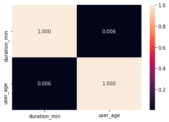

```python
time_and_age= ['duration_min','user_age']
sb.heatmap(fordbike[time_and_age].corr(),annot=True,fmt='.3f',cmap='rocket');
```

##### visualizing correlation information with scatter plot

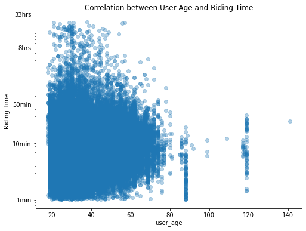

```python
plt.figure(figsize=[8,6])
sb.regplot(data=fordbike,x='user_age',y='duration_min',fit_reg=False,scatter_kws={'alpha':1/3});
plt.yscale('log')
plt.yticks(y_loc,y_labels);
plt.ylabel('Riding Time');
plt.title('Correlation between User Age and Riding Time')
```

### Observation

> This company would like to pay more attention to these age group of poeple as most of their revenue comes from them.

### Question 2

What is the distribution of one category of people group by a second category?

##### - user_type grouped by age_group

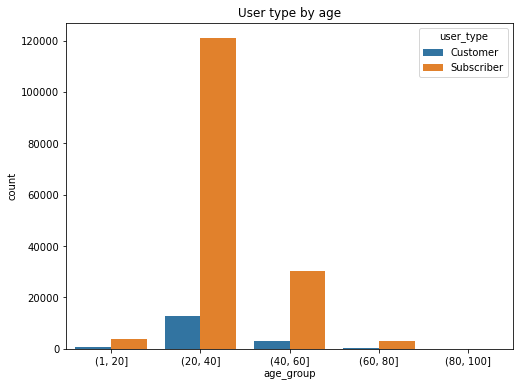

```python
plt.figure(figsize=[8,6])
# sb.set_style('whitegrid')
# sb.set_context("poster")

sb.countplot(data=fordbike,x='age_group',hue='user_type').set(title='User type by age');
```

##### user_type grouped by gender

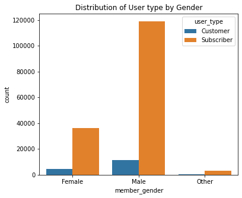

```python
plt.figure(figsize=[6,5])
sb.countplot(data=fordbike,x='member_gender',hue='user_type').set(title='Distribution of User type by Gender');
```

##### age_group grouped by member_gender

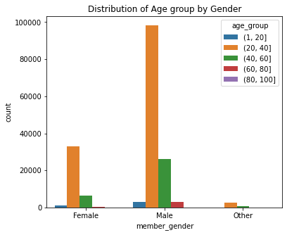

```python
plt.figure(figsize=[6,5])
sb.countplot(data=fordbike,x='member_gender',hue='age_group').set(title='Distribution of Age group by Gender');
```

### Observation

There is no clear group that suggests certain age group tend to be subscribers than customers as all categories are proportionally distributed over various age groups. Instead the data maintains the trend that people age 20-40,Male,Subscribers engage more in interaction with offerings of the ford biking service.

> This company might want to pay more attention to MALE SUBSCRIBERS BETWEEN 20-40 YEARS old as they have higher number patronising them.

### Question 3

Is there any relationship between duration_mins and user type?

##### statistics visualization

```python
fordbike.groupby('user_type')['duration_min'].median()
```

```
user_type
Customer      13.000000
Subscriber     8.166667
Name: duration_min, dtype: float64
```

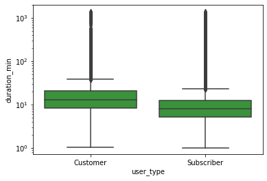

```python
# sb.barplot(data=fordbike,x='age_group',y='duration_min',hue='user_type');
# plt.yscale('log')
g=sb.boxplot(data=fordbike,x='user_type',y='duration_min',color=color);
plt.yscale('log');
```

##### mean duration mins

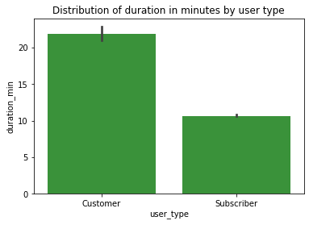

```python
# checking the duration_min mean for customer vs subscriber
sb.barplot(data=fordbike,x='user_type',y='duration_min',color=color).set(title='Distribution of duration in minutes by user type');
```

##### total duration minutes

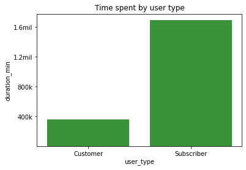

```python
# create a new data frame to use for this analysis
new_sum=fordbike.groupby('user_type')['duration_min'].sum().reset_index()
sb.barplot(data=new_sum,x='user_type',y='duration_min',color=color);
yloc=[400000,800000,1200000,1600000]
y_labels=['400k','800k','1.2mil','1.6mil']
plt.title('Time spent by user type')
plt.yticks(yloc,y_labels);
```

### Observation

Subscriber type might be more in number but customer type have more riding time on average.Also though customer type are less in number in the data they have higher mean and median value.

> Again it will benefit the company to pay special attention not only to the subscribers group because customers too show significant engagement based on average time spent using the service.

### Question 4

What is total riding duration for Men vs Women vs Others?

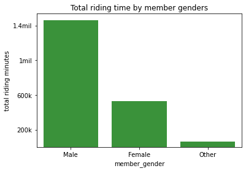

```python
new_sum=fordbike.groupby('member_gender')['duration_min'].sum().reset_index()
order=fordbike.member_gender.value_counts().index
sb.barplot(data=new_sum,x='member_gender',y='duration_min',color=color,order=order);
yloc=[200000,600000,1000000,1400000]
y_labels=['200k','600k','1mil','1.4mil']
plt.yticks(yloc,y_labels);
plt.ylabel('total riding minutes');
plt.title('Total riding time by member genders')
```

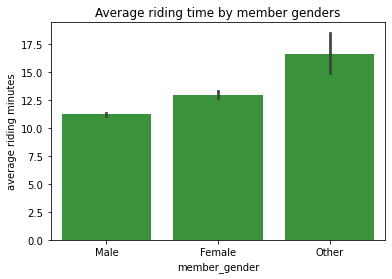

```python
# new_sum=fordbike.groupby('member_gender')['duration_min'].mean().reset_index()
# order=fordbike.member_gender.value_counts().index
# sb.barplot(data=new_sum,x='member_gender',y='duration_min',color=color,order=order);

sb.barplot(data=fordbike,x='member_gender',y='duration_min',color=color,order=order);
plt.ylabel('average riding minutes');
plt.title('Average riding time by member genders')
```

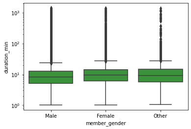

```python
g=sb.boxplot(data=fordbike,x='member_gender',y='duration_min',order=order,color=color);
plt.yscale('log');
```

### Observation

This member_gender also follows the same trend as the user_type variable as categories with lower counts tend to have higher means and median values suggesting that these categories are also very important

### Question 5

What is the total distribution of gender across differnt days of the week?

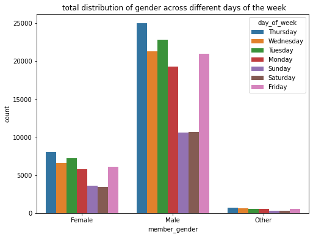

```python
plt.figure(figsize=[8,6])
sb.countplot(data=fordbike,x='member_gender',hue='day_of_week').set(title=' total distribution of gender across different days of the week');
```

### Observation

There are no suprises as males still dominate engagement in all the days due to their large number

### Question 6

Are there any suprising correlations in the data with non interest features?

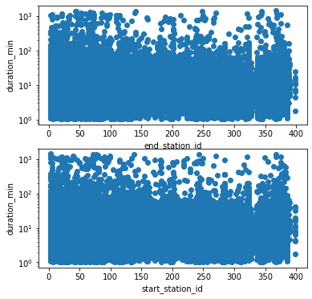

```python
# checking for correlation between duration time and end_station_id,start_station_id
def plot_corr(data,var1,var2,):
    variables=[var1,var2,]
    fig, ax = plt.subplots(nrows=2, figsize = [6,6])

    for i in range(len(variables)):
        var = variables[i]
        ax[i].scatter(data = data, x = var,y='duration_min')
        ax[i].set_yscale('log')
        ax[i].set_xlabel(var);
        ax[i].set_ylabel('duration_min')

plot_corr(fordbike,'end_station_id','start_station_id',)
```

[figure not shown]

```python
# checking for relationship between end_station_id and start_station_id
plt.scatter(data=fordbike,x='end_station_id',y='start_station_id');
plt.xlabel('end_station_id');
plt.ylabel('duration_min');
plt.title('relationship between end_station_id and start_station_id');
```

### Observation

No correlation found for these variables and duration_mins. Although the plot of the stations id's looks like a blueprint.

### Relationships observed in this part of the investigation.

At this stage of the analysis i have already started seeing answers to the question i posed to the dataset. I first of all noticed massive engagement of users between the age of 20-40 years over other users. I also noticed that subscriber type users had more engagement than customer type based on number but further investigation revealed that the customer type also had engagements when it comes to average riding duration even though they are smaller in number. Similar trend is seen in the member_gender column where the other fewer genders had more mean riding duration.This means 20-40 year old subscriber males had higher total riding duration time but shorter riding duration time on average. This means they engage in shorter trips spending less time with the service.

### Interesting relationships between the other features (not the main feature(s) of interest).

I didn't notice any correlation between duration_min and some other features but there was an interesting plot when i plotted end_station_id with start_station_id. It gave a PLOT that looked like an actual set-out PLOT of land, or a blue print if you like.

## Multivariate Exploration

The main thing I want to explore in this part of the analysis is how the categorical measures of quality relate with duration_min

### Question 1

To visualize the statistics of duration_min over user_type and member_gender variables

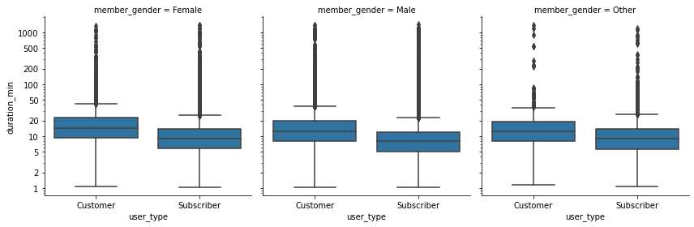

```python
### Question
g = sb.FacetGrid(data = fordbike, col = 'member_gender', size = 4)
g.map(sb.boxplot, 'user_type', 'duration_min');
plt.yscale('log')
y_loc=[1,2,5,10,20,50,100,200,500,1000]
y_ticks=['{}'.format(v) for v in y_loc]
plt.yticks(y_loc,y_ticks);
```

##### Observation

- Subscribers have higher numbers but have lesser median values as compared to Customer type

[figure not shown]

```python
plt.figure(figsize = [15,6])

order=fordbike.member_gender.value_counts().index
plt.subplot(1,3,1)

sb.pointplot(data = fordbike, x = 'member_gender', y = 'duration_min', hue = 'user_type',linestyles='',dodge=0.4);
plt.legend(loc = 9, ncol = 3, framealpha = 0.5, title = 'member_gender');
plt.subplot(1,3,2)
sb.pointplot(data = fordbike, x = 'member_gender', y = 'duration_min', hue = 'age_group',linestyles='',dodge=0.4);
plt.legend(loc = 9, ncol = 3, framealpha = 0.5, title = 'age_group');
plt.subplot(1,3,3)
sb.pointplot(data = fordbike, x = 'member_gender', y = 'duration_min', hue = 'bike_share_for_all_trip',linestyles='',dodge=0.4);
plt.legend(loc = 9, ncol = 3, framealpha = 0.5, title = 'bike_share_for_all_trip');
```

##### Observation

- General trend of categories with lesser numbers having higher duration minutes on average.
- Very high variance in distribution of the "other gender".
- 80-100 age group have the lowest average duration minutes as one would expect.
- Very low variance in subscriber between 20-40years who dont use the bike share for all service.

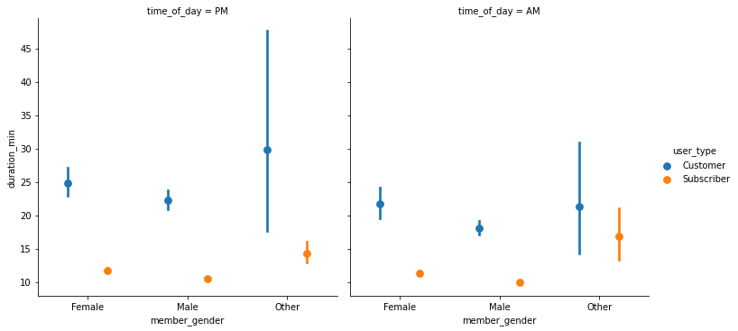

```python
sb.catplot(data=fordbike,
           x='member_gender',
           y='duration_min',
           hue='user_type',
           kind='point',
           dodge=0.4,
           col='time_of_day',
           linestyles='');
```

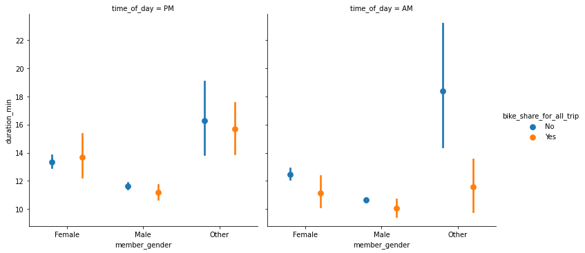

```python
sb.catplot(data=fordbike,
           x='member_gender',
           y='duration_min',
           hue='bike_share_for_all_trip',
           kind='point',
           dodge=0.4,
           col='time_of_day',
           linestyles='');
```

##### Observation

- As usual there is the high variance in the "other" gender category for both Morinings and Evenings.
- The group that brings more revenue to the company are Male Subscribers 20-40 years old that dont use the bike_share_for_all service
- The group that generates the least income are poeple of the "other" gender that are Subscriber type that patronise the bike_share_for_all service

### Relationships observed in this part of the investigation.

Extending relationships between duration minutes and the other qualitative variables here made it easier to clearly see and understand trends in the data and further come up with the categories that interact with the Ford Go-bike services more. This plots show that:

- As usual there is the high variance in the "other" gender category for both Morinings and Evenings.
- The group that brings more revenue to the company are Male Subscribers 20-40 years old that dont use the bike_share_for_all service
- The group that generates the least income are poeple of the "other" gender that are Subscriber type that patronise the bike_share_for_all service